# Characterising rocky intertidal biodiversity using environmental DNA metabarcoding from local to national scales

### Beta diversity

While our stats are performed in PRIMER7, we create our NMDS and dissimilarity plots here.

```r
# filter out any NAs for variables of interest
physeq_beta <- ps_filter(phylo_rocky_eDNA, shorePosition != "NA")
physeq_beta <- ps_filter(physeq_beta, country != "NA")
physeq_beta <- prune_samples(sample_sums(physeq_beta) > 0, physeq_beta)

# convert to P/A
physeq_beta_PA <- microbiome::transform(physeq_beta,"pa")

# split by gene
pseq_CO1_pruned <- ps_filter(physeq_beta_PA, primer == "CO1")
pseq_18S_pruned <- ps_filter(physeq_beta_PA, primer == "18S")
```

#### NMDS plots

```r
ord.nmds.jaccard.CO1 <- ordinate(pseq_CO1_pruned, method = "NMDS", distance =
                                   "jaccard", k = 3)
```

```
*** Best solution repeated 1 times
```

```r
stress_value_jaccard_CO1 <- ord.nmds.jaccard.CO1$stress
```

```r
ord.nmds.jaccard.18S <- ordinate(pseq_18S_pruned, method = "NMDS", distance =
                                   "jaccard", k = 3)
```

```
*** Best solution was not repeated -- monoMDS stopping criteria:
    19: no. of iterations >= maxit
     1: stress ratio > sratmax
```

```r
stress_value_jaccard_18S <- ord.nmds.jaccard.18S$stress
```

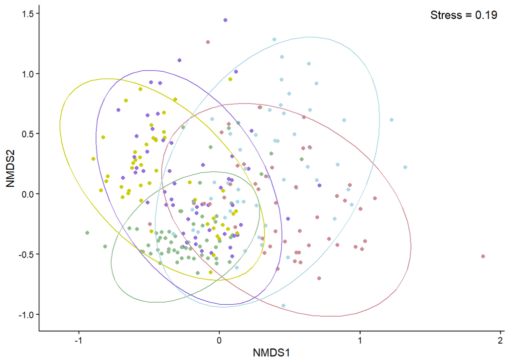

```r
NMDS_region_CO1_jaccard <- plot_ordination(pseq_CO1_pruned, ord.nmds.jaccard.CO1, color="country")+
  scale_colour_manual(values = c("Scotland" = "darkseagreen",
                                 "North Wales" = "lightpink3",
                                 "Northeast England" = "yellow3",
                                 "South Wales" = "lightblue",
                                 "Southwest England" = "mediumpurple")) +
  theme_classic()+
  #theme(legend.position = "none")+
  annotate("text", x = Inf, y = Inf, label = paste("Stress =", round(stress_value_jaccard_CO1, 3)),
           size = 4, hjust = 1.1, vjust = 1.5)+
  #stat_ellipse(aes(group = interaction(country, shorePosition)), type = "t", level = 0.95, linetype = 1, size = 0.5)+
  stat_ellipse(aes(group = country), type = "t", level = 0.95, linetype = 1, size = 0.5)+
  #annotate("text", x = -0.6, y = 0.6, label = paste("CO1"),
           #size = 4)+
  labs(color = "Region") +
  theme(legend.position = "bottom") +
  theme(legend.position = "none")+
  guides(colour = guide_legend(nrow = 2, byrow = TRUE))

NMDS_region_CO1_jaccard
```

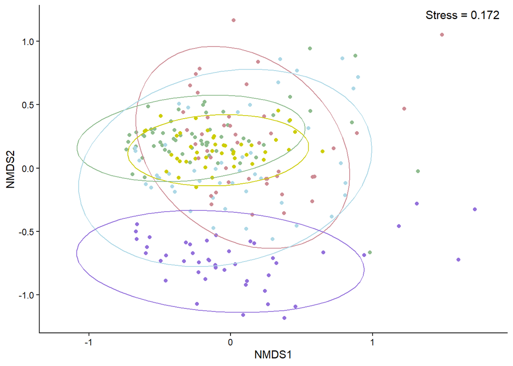

```r
NMDS_region_18S_jaccard <- plot_ordination(pseq_18S_pruned, ord.nmds.jaccard.18S, color="country")+
  scale_colour_manual(values = c("Scotland" = "darkseagreen",
                                 "North Wales" = "lightpink3",
                                 "Northeast England" = "yellow3",
                                 "South Wales" = "lightblue",
                                 "Southwest England" = "mediumpurple")) +
  theme_classic()+
  theme(legend.position = "none")+
  annotate("text", x = Inf, y = Inf, label = paste("Stress =", round(stress_value_jaccard_18S, 3)),
           size = 4, hjust = 1.1, vjust = 1.5)+
  stat_ellipse(aes(group = country), type = "t", linetype = 1, size = 0.5)+
  #annotate("text", x = -1.1, y = 0.9, label = paste("18S"),
           #size = 4)+
  xlim(-1.2,1.8)+ #to remove weird outlier
  labs(color = "Region")


NMDS_region_18S_jaccard
```

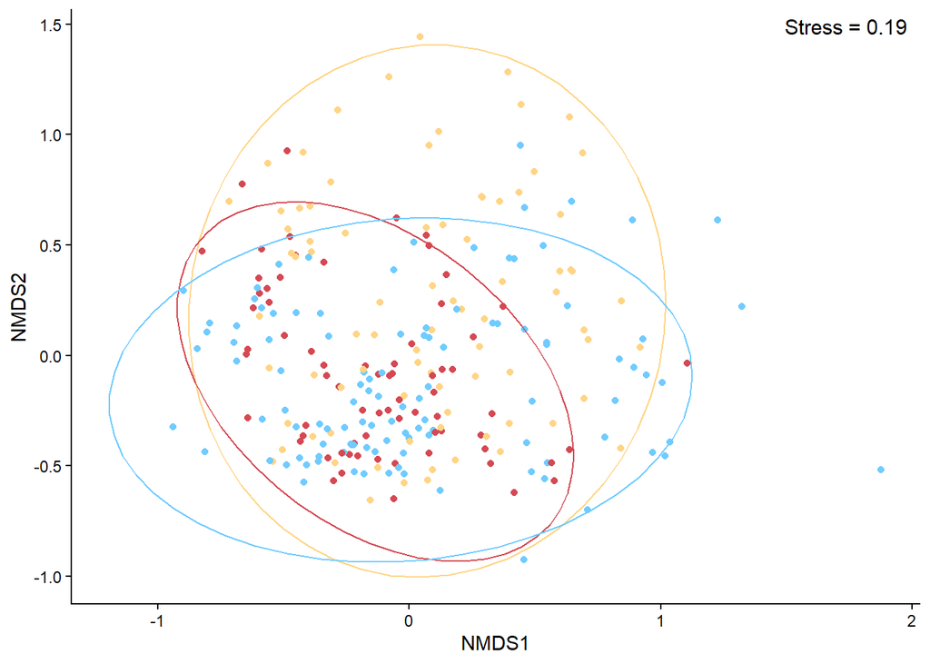

```r
NMDS_type_CO1_jaccard<- plot_ordination(pseq_CO1_pruned, ord.nmds.jaccard.CO1, color="shorePosition") +
  scale_colour_manual(values = c("Low" = lowshore_colour,
                               "High" = highshore_colour,
                               'Open Water' = openwater_colour)) +
  theme_classic()+
  #theme(legend.position = "none")+
  annotate("text", x = Inf, y = Inf, label = paste("Stress =", round(stress_value_jaccard_CO1, 3)),
           size = 4, hjust = 1.1, vjust = 1.5)+
  stat_ellipse(aes(group = shorePosition), type = "t", linetype = 1, size = 0.5)+
  #annotate("text", x = -0.6, y = 0.6, label = paste("CO1"),
           #size = 4)+
  labs(color = "Shore position") +
  theme(legend.position = "none") +
  guides(colour = guide_legend(nrow = 1, byrow = TRUE))

NMDS_type_CO1_jaccard
```

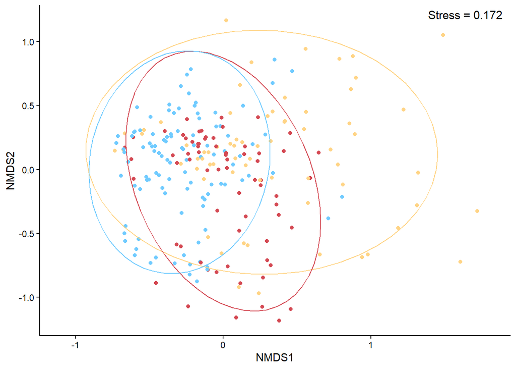

```r
NMDS_type_18S_jaccard <- plot_ordination(pseq_18S_pruned, ord.nmds.jaccard.18S, color="shorePosition") +
  scale_colour_manual(values = c("Low" = lowshore_colour,
                                 "High" = highshore_colour,
                                 'Open Water' = openwater_colour)) +
  theme_classic()+
  theme(legend.position = "none")+
  annotate("text", x = Inf, y = Inf, label = paste("Stress =", round(stress_value_jaccard_18S, 3)),
           size = 4, hjust = 1.1, vjust = 1.5)+
  stat_ellipse(aes(group = shorePosition), type = "t", linetype = 1, size = 0.5)+
  #annotate("text", x = -1.1, y = 1, label = paste("18S"),
           #size = 4)+
  xlim(-1.1, 1.8)+
  labs(color = "Shore position")

NMDS_type_18S_jaccard
```

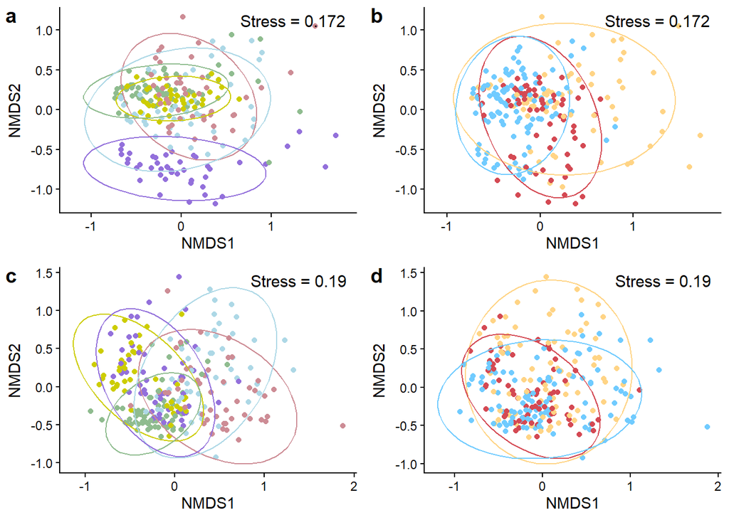

```r
NMDS_jaccard_all<- cowplot::plot_grid(NMDS_region_18S_jaccard, NMDS_type_18S_jaccard,NMDS_region_CO1_jaccard, NMDS_type_CO1_jaccard, labels = c("a", "b", "c", "d"), ncol = 2, align = "hv")

NMDS_jaccard_all
```

```r
ggsave("Figures/NMDS_jaccard_all.png", NMDS_jaccard_all, units = "mm", width = 240, height = 240)
```

#### Check for homogeneity of dispersion

```r
#CO1 - region
jaccard_dist_CO1 <- distance(pseq_CO1_pruned, method = "jaccard")
region <- sample_data(pseq_CO1_pruned)$country
bd_CO1_r <- betadisper(d = jaccard_dist_CO1, group = region, type = "centroid")
permutest(bd_CO1_r) #signficant
```

```
Permutation test for homogeneity of multivariate dispersions
Permutation: free
Number of permutations: 999

Response: Distances
           Df  Sum Sq   Mean Sq      F N.Perm Pr(>F)
Groups      4 0.09054 0.0226354 6.6426    999  0.001 ***
Residuals 257 0.87575 0.0034076
---
Signif. codes:  0 '***' 0.001 '**' 0.01 '*' 0.05 '.' 0.1 ' ' 1
```

```r
#CO1 - shore height
shore_height <- sample_data(pseq_CO1_pruned)$shorePosition
bd_CO1_sh <- betadisper(d =jaccard_dist_CO1, group = shore_height, type = "centroid")
permutest(bd_CO1_sh) #signficant
```

```
Permutation test for homogeneity of multivariate dispersions
Permutation: free
Number of permutations: 999

Response: Distances
           Df  Sum Sq   Mean Sq      F N.Perm Pr(>F)
Groups      2 0.05472 0.0273579 14.409    999  0.001 ***
Residuals 259 0.49175 0.0018987
---
Signif. codes:  0 '***' 0.001 '**' 0.01 '*' 0.05 '.' 0.1 ' ' 1
```

```r
#CO1 - sites
sites <- sample_data(pseq_CO1_pruned)$verbatimLocality
bd_CO1_s <- betadisper(d =jaccard_dist_CO1, group = sites, type = "centroid")
permutest(bd_CO1_s) #signficant
```

```
Permutation test for homogeneity of multivariate dispersions
Permutation: free
Number of permutations: 999

Response: Distances
           Df  Sum Sq  Mean Sq      F N.Perm Pr(>F)
Groups     31 0.97195 0.031353 7.3548    999  0.001 ***
Residuals 230 0.98049 0.004263
---
Signif. codes:  0 '***' 0.001 '**' 0.01 '*' 0.05 '.' 0.1 ' ' 1
```

```r
#18S - region
jaccard_dist_18S <- distance(pseq_18S_pruned, method = "jaccard")
region <- sample_data(pseq_18S_pruned)$country
bd_18S_r <- betadisper(d = jaccard_dist_18S, group = region, type = "centroid")
permutest(bd_18S_r) #signficant
```

```
Permutation test for homogeneity of multivariate dispersions
Permutation: free
Number of permutations: 999

Response: Distances
           Df  Sum Sq  Mean Sq     F N.Perm Pr(>F)
Groups      4 0.15568 0.038921 7.453    999  0.001 ***
Residuals 237 1.23766 0.005222
---
Signif. codes:  0 '***' 0.001 '**' 0.01 '*' 0.05 '.' 0.1 ' ' 1
```

```r
#18S - shore height
shore_height <- sample_data(pseq_18S_pruned)$shorePosition
bd_18S_sh <- betadisper(d =jaccard_dist_18S, group = shore_height, type = "centroid")
permutest(bd_18S_sh) #signficant
```

```
Permutation test for homogeneity of multivariate dispersions
Permutation: free
Number of permutations: 999

Response: Distances
           Df  Sum Sq  Mean Sq      F N.Perm Pr(>F)
Groups      2 0.09253 0.046267 15.131    999  0.001 ***
Residuals 239 0.73082 0.003058
---
Signif. codes:  0 '***' 0.001 '**' 0.01 '*' 0.05 '.' 0.1 ' ' 1
```

```r
#18S - sites
sites <- sample_data(pseq_18S_pruned)$verbatimLocality
bd_18S_s <- betadisper(d =jaccard_dist_18S, group = sites, type = "centroid")
permutest(bd_18S_s) #signficant
```

```
Permutation test for homogeneity of multivariate dispersions
Permutation: free
Number of permutations: 999

Response: Distances
           Df Sum Sq  Mean Sq      F N.Perm Pr(>F)
Groups     31 1.4619 0.047158 9.4475    999  0.001 ***
Residuals 210 1.0482 0.004992
---
Signif. codes:  0 '***' 0.001 '**' 0.01 '*' 0.05 '.' 0.1 ' ' 1
```

#### Pairwise dissimilarity boxplots

```r
jaccard_dist_CO1 <- phyloseq::distance(pseq_CO1_pruned, method="jaccard")

# format matrix to long
jaccard_dist_CO1_mat <- as.matrix(jaccard_dist_CO1)
longData_CO1<-melt(jaccard_dist_CO1_mat)
longData_CO1<-longData_CO1[longData_CO1$value!=0,]
```

```r
metadf <- data.frame(sample_data(pseq_CO1_pruned))
metadf_shore <- metadf %>% subset(select = c("fullID", "verbatimLocality", "shorePosition", "country"))
```

```r
# Join longData_CO1 with metadf_shore to get Var1_position
longData_CO1 <- longData_CO1 %>%
  left_join(
    metadf_shore %>%
      dplyr::select(fullID, Var1_position = shorePosition),
    by = c("Var1" = "fullID")
  )

# Join longData_CO1 with metadf_shore again to get Var2_position
longData_CO1 <- longData_CO1 %>%
  left_join(
    metadf_shore %>%
      dplyr::select(fullID, Var2_position = shorePosition),
    by = c("Var2" = "fullID")
  )

# Join longData_CO1 with metadf_shore again to get Var2_position
longData_CO1 <- longData_CO1 %>%
  left_join(
    metadf_shore %>%
      dplyr::select(fullID, Var1_site = verbatimLocality),
    by = c("Var1" = "fullID")
  )

# Join longData_CO1 with metadf_shore again to get Var2_position
longData_CO1 <- longData_CO1 %>%
  left_join(
    metadf_shore %>%
      dplyr::select(fullID, Var2_site = verbatimLocality),
    by = c("Var2" = "fullID")
  )

# Join longData_CO1 with metadf_shore again to get Var2_position
longData_CO1 <- longData_CO1 %>%
  left_join(
    metadf_shore %>%
      dplyr::select(fullID, Var1_country = country),
    by = c("Var1" = "fullID")
  )

# Join longData_CO1 with metadf_shore again to get Var2_position
longData_CO1 <- longData_CO1 %>%
  left_join(
    metadf_shore %>%
      dplyr::select(fullID, Var2_country = country),
    by = c("Var2" = "fullID")
  )

# Create the comparison variable
longData_CO1 <- longData_CO1 %>%
  mutate(
    # Create a consistent comparison column by sorting positions
    comparison = pmap_chr(list(Var1_position, Var2_position), function(v1, v2) {
      if (v1 == v2) {
        "Within shore position"
      } else {
        sorted <- sort(c(v1, v2)) # Sort the positions
        paste(sorted, collapse = "") # Concatenate the sorted positions
      }
    }),
    sameSite = Var1_site == Var2_site,
    samePosition = Var1_position == Var2_position
  )

longData_CO1$comparison[longData_CO1$comparison == "HighOpen Water"] = "HighOpenWater"
longData_CO1$comparison[longData_CO1$comparison == "LowOpen Water"] = "LowOpenWater"
longData_CO1_samesites <- longData_CO1 %>% filter(sameSite == TRUE)
```

```r
# Plotting the boxplot using ggplot2
standard_error <- function(x) {
  sd(x, na.rm = TRUE) / sqrt(length(x))
}

which(longData_CO1_samesites$Var1_site != longData_CO1_samesites$Var2_site)
```

```
integer(0)
```

```r
# Calculate the averages for each group site
averages <- longData_CO1_samesites %>%
  dplyr::group_by(comparison, Var1_site) %>%
  dplyr::summarise(mean_value = mean(value, na.rm = TRUE), .groups = 'drop',
                   standard_error = standard_error(value))

averages
```

```
# A tibble: 98 × 4
   comparison Var1_site        mean_value standard_error
   <chr>      <chr>                 <dbl>          <dbl>
 1 HighLow    Aberystwyth           0.756        0.0129
 2 HighLow    Broad Haven           0.777        0.00683
 3 HighLow    Castlehead Rocks      0.782        0.00661
 4 HighLow    Filey Brigg           0.694        0.0102
 5 HighLow    Great Orme East       0.559        0.0105
 6 HighLow    Lizard Point          0.779        0.0118
 7 HighLow    Looe                  0.807        0.0327
 8 HighLow    Menai Bridge          0.780        0.0227
 9 HighLow    Murkle Bay            0.870        0.0116
10 HighLow    Newton Point          0.797        0.0237
# ℹ 88 more rows
```

```r
# Calculate the averages for each group region
averages_regions <- longData_CO1_samesites %>%
  dplyr::group_by(comparison, Var1_country) %>%
  dplyr::summarise(mean_value = mean(value, na.rm = TRUE), .groups = 'drop',
                   standard_error = standard_error(value))

averages_regions
```

```
# A tibble: 20 × 4
   comparison            Var1_country      mean_value standard_error
   <chr>                 <chr>                  <dbl>          <dbl>
 1 HighLow               North Wales            0.735        0.0183
 2 HighLow               Northeast England      0.719        0.0108
 3 HighLow               Scotland               0.711        0.0111
 4 HighLow               South Wales            0.808        0.00692
 5 HighLow               Southwest England      0.788        0.00821
 6 HighOpenWater         North Wales            0.770        0.0104
 7 HighOpenWater         Northeast England      0.774        0.0101
 8 HighOpenWater         Scotland               0.730        0.0133
 9 HighOpenWater         South Wales            0.846        0.00566
10 HighOpenWater         Southwest England      0.798        0.00911
11 LowOpenWater          North Wales            0.732        0.0122
12 LowOpenWater          Northeast England      0.661        0.00795
13 LowOpenWater          Scotland               0.734        0.00610
14 LowOpenWater          South Wales            0.772        0.0120
15 LowOpenWater          Southwest England      0.667        0.00624
16 Within shore position North Wales            0.634        0.0127
17 Within shore position Northeast England      0.638        0.00826
18 Within shore position Scotland               0.575        0.00948
19 Within shore position South Wales            0.640        0.00857
20 Within shore position Southwest England      0.687        0.0108
```

```r
# Calculate the averages for each group region
averages_compare_CO1 <- longData_CO1_samesites %>%
  dplyr::group_by(comparison) %>%
  dplyr::summarise(mean_value = mean(value, na.rm = TRUE), .groups = 'drop',
                   standard_error = standard_error(value))
averages_compare_CO1
```

```
# A tibble: 4 × 3
  comparison            mean_value standard_error
  <chr>                      <dbl>          <dbl>
1 HighLow                    0.752        0.00513
2 HighOpenWater              0.784        0.00480
3 LowOpenWater               0.705        0.00431
4 Within shore position      0.633        0.00478
```

```r
# Define the four unique comparisons you're interested in
required_comparisons <- c("HighOpenWater",
                          "HighLow",
                          "LowOpenWater",
                          "Within shore position")

# Filter the sites that have all required comparisons
filtered_sites <- longData_CO1_samesites #%>%
  #dplyr::group_by(Var1_site) %>%
  #dplyr::filter(all(required_comparisons %in% comparison)) %>%
  #dplyr::ungroup()
```

```r
comparison_order <- c("High vs Open Water",
                      "High vs Low",
                      "Low vs Open Water",
                      "Same shore position")

# needed if using full sampling effort sites only
site_order_reduced <- c(
  "Scourie",
  "Skerray",
  "Murkle Bay",
  "Wick", #Scotland
  "Porth Swtan",
  "Rhosneigr",#North Wales
  "Castlehead Rocks",
  "Filey Brigg",
  "Newton Point",
  "Rumbling Kern",
  "Scalby Mills",#Northumbria
  "Aberystwyth",
  "Broad Haven",
  "West Angle",#South Wales
  "Lizard Point",
  "Looe",
  "Sennen Cove",
  "St Ives",
  "Trevone" #Cornwall
)

# Reorder the factor levels for the comparison variable
filtered_sites$comparison <- factor(
  filtered_sites$comparison,
  levels = c(
    "HighOpenWater",
    "HighLow",
    "LowOpenWater",
    "Within shore position"
  )
)
```

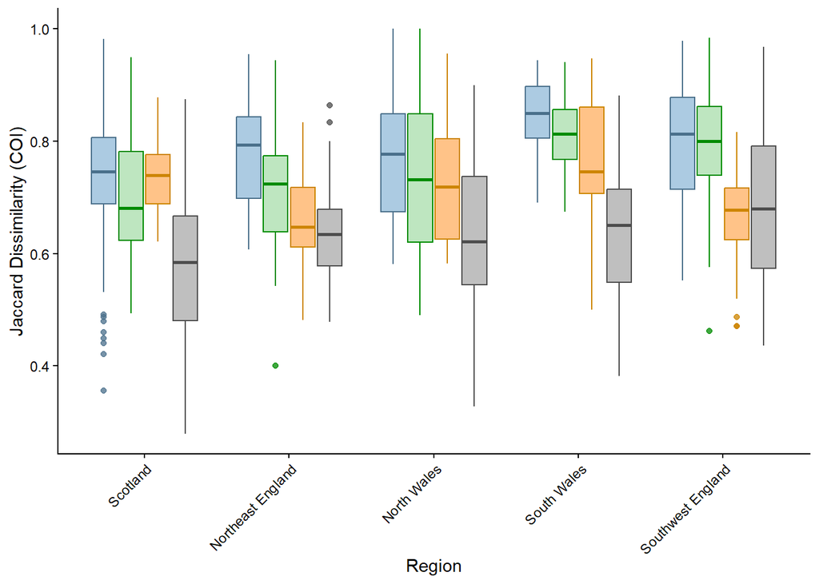

```r
compare_jaccard_regions <- ggplot(filtered_sites, aes(x = Var1_country, y = value, fill = comparison, colour = comparison)) +
  geom_boxplot(alpha = 0.5) +
  #geom_point(position = position_jitterdodge(dodge.width = .5), alpha = 0.2) +
  #geom_text(data = averages, aes(x = Var1_site, y = mean_value, label = round(mean_value, 2)),
  #vjust = -1.8, color = "black", size = 3.5, position = position_dodge(width = 0.75)) +
  labs(x = "Region",
       y = "Jaccard Dissimilarity (COI)") +
  scale_fill_manual(values = c("HighLow" = "#7DCE82",
                               "Within shore position" = "grey50",
                               "LowOpenWater" = "#FF8811",
                               "HighOpenWater" = "#5998C5"),
                    labels = c("HighLow" = "High vs Low",
                               "HighOpenWater" = "High vs Open Water",
                               "LowOpenWater" = "Low vs Open Water",
                               "Within shore position" = "Same shore height"),
                    name = "Shore Height Comparison") +
  scale_colour_manual(values = c("HighLow" = "green4",
                                 "Within shore position" = "grey30",
                                 "LowOpenWater" = "orange3",
                                 "HighOpenWater" = "skyblue4"),
                      labels = c("HighLow" = "High vs Low",
                                 "HighOpenWater" = "High vs Open Water",
                                 "LowOpenWater" = "Low vs Open Water",
                                 "Within shore position" = "Same shore height"),
                      name = "Shore Height Comparison")+
  theme_classic() +
  scale_x_discrete(limits = country_order) +
  theme(axis.text.x = element_text(angle = 45, hjust = 1),
        legend.position = 'none') + # Remove x-axis title)
scale_y_continuous(labels = scales::number_format(accuracy = 0.1))

compare_jaccard_regions
```

Same again for 18S.

```r
#Produce distance matrix
jaccard_dist_18S <- phyloseq::distance(pseq_18S_pruned, method="jaccard")

#subset meta data for shore heights
metadf <- data.frame(sample_data(pseq_18S_pruned))
metadf_shore <- metadf %>% subset(select = c("fullID", "verbatimLocality", "shorePosition", "country"))

# format matrix to long
jaccard_dist_18S_mat <- as.matrix(jaccard_dist_18S)
longData_18S<-melt(jaccard_dist_18S_mat)
longData_18S<-longData_18S[longData_18S$value!=0,]
```

```r
# Join longData_CO1 with metadf_shore to get Var1_position
longData_18S <- longData_18S %>%
  left_join(
    metadf_shore %>%
      dplyr::select(fullID, Var1_position = shorePosition),
    by = c("Var1" = "fullID")
  )

# Join longData_CO1 with metadf_shore again to get Var2_position
longData_18S <- longData_18S %>%
  left_join(
    metadf_shore %>%
      dplyr::select(fullID, Var2_position = shorePosition),
    by = c("Var2" = "fullID")
  )

# Join longData_CO1 with metadf_shore again to get Var2_position
longData_18S <- longData_18S %>%
  left_join(
    metadf_shore %>%
      dplyr::select(fullID, Var1_site = verbatimLocality),
    by = c("Var1" = "fullID")
  )

# Join longData_CO1 with metadf_shore again to get Var2_position
longData_18S <- longData_18S %>%
  left_join(
    metadf_shore %>%
      dplyr::select(fullID, Var2_site = verbatimLocality),
    by = c("Var2" = "fullID")
  )

# Join longData_CO1 with metadf_shore again to get Var2_position
longData_18S <- longData_18S %>%
  left_join(
    metadf_shore %>%
      dplyr::select(fullID, Var1_country = country),
    by = c("Var1" = "fullID")
  )

# Join longData_CO1 with metadf_shore again to get Var2_position
longData_18S <- longData_18S %>%
  left_join(
    metadf_shore %>%
      dplyr::select(fullID, Var2_country = country),
    by = c("Var2" = "fullID")
  )

# Create the comparison variable
longData_18S <- longData_18S %>%
  mutate(
    # Create a consistent comparison column by sorting positions
    comparison = pmap_chr(list(Var1_position, Var2_position), function(v1, v2) {
      if (v1 == v2) {
        "Within shore position"
      } else {
        sorted <- sort(c(v1, v2)) # Sort the positions
        paste(sorted, collapse = "") # Concatenate the sorted positions
      }
    }),
    sameSite = Var1_site == Var2_site,
    samePosition = Var1_position == Var2_position
  )

longData_18S$comparison[longData_18S$comparison == "HighOpen Water"] = "HighOpenWater"
longData_18S$comparison[longData_18S$comparison == "LowOpen Water"] = "LowOpenWater"

longData_18S_samesites <- longData_18S %>% filter(sameSite == TRUE)

which(longData_18S_samesites$Var1_site != longData_18S_samesites$Var2_site)
```

```
integer(0)
```

```r
# Calculate the averages for each group
averages <- longData_18S_samesites %>%
  dplyr::group_by(comparison, Var1_site) %>%
  dplyr::summarise(
    mean_value = mean(value, na.rm = TRUE),
    .groups = 'drop',
    standard_error = standard_error(value)
  )

averages
```

```
# A tibble: 98 × 4
   comparison Var1_site        mean_value standard_error
   <chr>      <chr>                 <dbl>          <dbl>
 1 HighLow    Aberystwyth           0.493         0.0276
 2 HighLow    Broad Haven           0.778         0.0111
 3 HighLow    Castlehead Rocks      0.758         0.0183
 4 HighLow    Filey Brigg           0.548         0.0128
 5 HighLow    Great Orme East       0.456         0.0122
 6 HighLow    Lizard Point          0.702         0.0405
 7 HighLow    Looe                  0.810         0.0186
 8 HighLow    Menai Bridge          0.763         0.0198
 9 HighLow    Murkle Bay            0.736         0.0178
10 HighLow    Newton Point          0.659         0.0137
# ℹ 88 more rows
```

```r
# Calculate the averages for each group
averages_regions <- longData_18S_samesites %>%
  dplyr::group_by(comparison, Var1_country) %>%
  dplyr::summarise(
    mean_value = mean(value, na.rm = TRUE),
    .groups = 'drop',
    standard_error = standard_error(value)
  )

averages_regions
```

```
# A tibble: 20 × 4
   comparison            Var1_country      mean_value standard_error
   <chr>                 <chr>                  <dbl>          <dbl>
 1 HighLow               North Wales            0.700        0.0217
 2 HighLow               Northeast England      0.573        0.0142
 3 HighLow               Scotland               0.627        0.0143
 4 HighLow               South Wales            0.703        0.0210
 5 HighLow               Southwest England      0.777        0.0162
 6 HighOpenWater         North Wales            0.741        0.0141
 7 HighOpenWater         Northeast England      0.661        0.0149
 8 HighOpenWater         Scotland               0.711        0.0124
 9 HighOpenWater         South Wales            0.748        0.0132
10 HighOpenWater         Southwest England      0.790        0.0148
11 LowOpenWater          North Wales            0.633        0.00728
12 LowOpenWater          Northeast England      0.586        0.00963
13 LowOpenWater          Scotland               0.682        0.00440
14 LowOpenWater          South Wales            0.739        0.0150
15 LowOpenWater          Southwest England      0.652        0.00876
16 Within shore position North Wales            0.518        0.0132
17 Within shore position Northeast England      0.479        0.0126
18 Within shore position Scotland               0.532        0.0103
19 Within shore position South Wales            0.519        0.0128
20 Within shore position Southwest England      0.578        0.0161
```

```r
averages_compare_18S <- longData_18S_samesites %>%
  dplyr::group_by(comparison) %>%
  dplyr::summarise(
    mean_value = mean(value, na.rm = TRUE),
    .groups = 'drop',
    standard_error = standard_error(value)
  )

averages_compare_18S
```

```
# A tibble: 4 × 3
  comparison            mean_value standard_error
  <chr>                      <dbl>          <dbl>
1 HighLow                    0.673        0.00848
2 HighOpenWater              0.731        0.00645
3 LowOpenWater               0.654        0.00491
4 Within shore position      0.527        0.00584
```

```r
# Filter the sites that have all required comparisons
filtered_sites_18S <- longData_18S_samesites #%>%
  #group_by(Var1_site) %>%
  #dplyr::filter(all(required_comparisons %in% comparison)) %>%
  #ungroup()

# Reorder the factor levels for the comparison variable
filtered_sites_18S$comparison <- factor(
  filtered_sites_18S$comparison,
  levels = c(
    "HighOpenWater",
    "HighLow",
    "LowOpenWater",
    "Within shore position"
  )
)
```

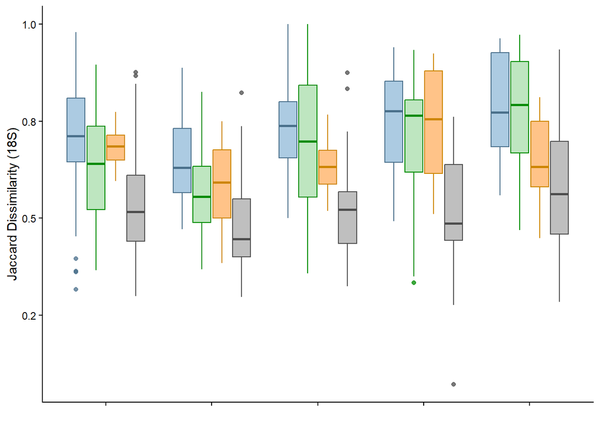

```r
compare_jaccard_regions_18S <- ggplot(filtered_sites_18S, aes(x = Var1_country, y = value, colour = comparison, fill = comparison)) +
  geom_boxplot(alpha = 0.5) +
  #geom_point(position = position_jitterdodge(dodge.width = .5), alpha = 0.2) +
  #geom_text(data = averages, aes(x = Var1_site, y = mean_value, label = round(mean_value, 2)),
  #vjust = -1.8, color = "black", size = 3.5, position = position_dodge(width = 0.75)) +
  labs(x = "",
       y = "Jaccard Dissimilarity (18S)") +
  scale_fill_manual(values = c("HighLow" = "#7DCE82",
                               "Within shore position" = "grey50",
                               "LowOpenWater" = "#FF8811",
                               "HighOpenWater" = "#5998C5"),
                    labels = c("HighLow" = "High vs Low",
                               "HighOpenWater" = "High vs Open Water",
                               "LowOpenWater" = "Low vs Open Water",
                               "Within shore position" = "Same shore height"),
                    name = "Shore Height Comparison") +
  scale_colour_manual(values = c("HighLow" = "green4",
                                 "Within shore position" = "grey30",
                                 "LowOpenWater" = "orange3",
                                 "HighOpenWater" = "skyblue4"),
                      labels = c("HighLow" = "High vs Low",
                                 "HighOpenWater" = "High vs Open Water",
                                 "LowOpenWater" = "Low vs Open Water",
                                 "Within shore position" = "Same shore height"),
                      name = "Shore Height Comparison")+
  theme_classic() +
  scale_x_discrete(limits = country_order) +
  theme(axis.text.x = element_blank(),
        legend.position = "none")   +
  scale_y_continuous(labels = scales::number_format(accuracy = 0.1))

compare_jaccard_regions_18S
```

```r
compare_jaccard <- ggplot(filtered_sites, aes(x = Var1_site, y = value, fill = comparison, colour = comparison)) +
  geom_boxplot(alpha = 0.5) +
  #geom_text(data = averages, aes(x = Var1_site, y = mean_value, label = round(mean_value, 2)),
            #vjust = -1.8, color = "black", size = 3.5, position = position_dodge(width = 0.75)) +
  labs(x = "Sites",
       y = "") +
  scale_fill_manual(values = c("HighLow" = "#7DCE82",
                               "Within shore position" = "grey50",
                               "LowOpenWater" = "#FF8811",
                               "HighOpenWater" = "#5998C5"),
                    labels = c("HighLow" = "High vs Low",
                               "HighOpenWater" = "High vs Open Water",
                               "LowOpenWater" = "Low vs Open Water",
                               "Within shore position" = "Same shore height"),
                    name = "Shore height comparison") +
  scale_colour_manual(values = c("HighLow" = "green4",
                                 "Within shore position" = "grey30",
                                 "LowOpenWater" = "orange3",
                                 "HighOpenWater" = "skyblue4"),
                      labels = c("HighLow" = "High vs Low",
                                 "HighOpenWater" = "High vs Open Water",
                                 "LowOpenWater" = "Low vs Open Water",
                                 "Within shore position" = "Same shore height"),
                      name = "Shore height comparison")+
  theme_classic() +
  scale_x_discrete(limits = site_order_reduced) +
  theme(axis.text.x = element_text(angle = 45, hjust = 1),
        legend.position = "bottom") +
  guides(colour = guide_legend(nrow = 1, byrow = TRUE)) +
  scale_y_continuous(labels = scales::number_format(accuracy = 0.1))

g_legend<-function(a.gplot){
  tmp <- ggplot_gtable(ggplot_build(a.gplot))
  leg <- which(sapply(tmp$grobs, function(x) x$name) == "guide-box")
  legend <- tmp$grobs[[leg]]
}

legend <- g_legend(compare_jaccard)
```

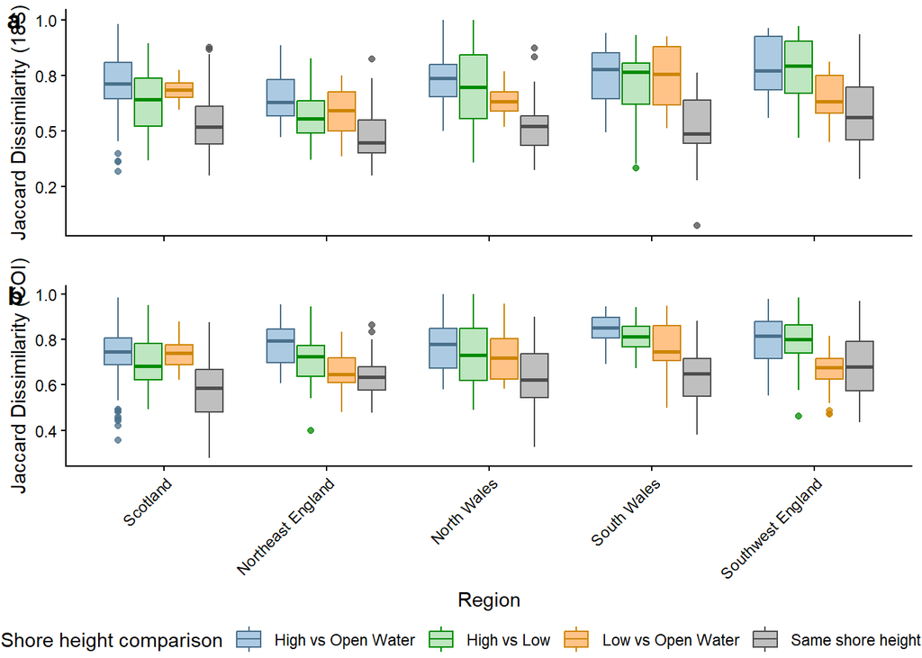

```r
region_jaccard <- cowplot::plot_grid(
  cowplot::plot_grid(compare_jaccard_regions_18S, compare_jaccard_regions, ncol = 1, labels = c("a", "b"), rel_heights = c(0.8, 1)), legend, ncol =1, rel_heights = c(1, 0.06))

ggsave(filename = "Figures/compare_jaccard_regionsonly_bothprimers.png", plot = region_jaccard ,
       device = "png", dpi = 600, units = "mm", height = 190, width = 200)

region_jaccard
```

#### Composition plots (shore height x site)

Let’s take a closer look at what might be driving differences between similar shore heights.

```r
# 1. Create output directory
output_dir <- "Figures/CompAcrossSitesSamples"
if (!dir.exists(output_dir)) {
  dir.create(output_dir)
}

# 2. Extract site names (verbatimLocality must be a sample variable)
site_names <- unique(sample_data(phylo_rocky_eDNA)$verbatimLocality)

# loop
for (site in site_names) {

  # Subset phyloseq object by site
  site_pseq <- subset_samples(phylo_rocky_eDNA, verbatimLocality == site)

  # Transform to relative abundance (compositional)
  pseq_relabund <- microbiome::transform(site_pseq, "compositional")

  # Aggregate rare phyla
  phylum_rareaggregate_pseq <- microbiome::aggregate_rare(
    pseq_relabund,
    level = "phylum",
    detection = 0.01,
    prevalence = 5 / 100
  )

  # Melt to data frame
  df <- psmelt(phylum_rareaggregate_pseq)

  # Plot manually
  p <- ggplot(df, aes(x = Sample, y = Abundance, fill = phylum)) +
    geom_bar(stat = "identity") +
    facet_wrap(~shorePosition, scales = "free_x") +
    xlab("Sample") +
    ylab("Relative abundance") +
    ggtitle(paste("Phylum relative abundance -", site)) +
    scale_fill_viridis_d(option = "turbo") +
    theme_bw() +
    theme(axis.text.x = element_text(angle = 90, hjust = 1))

  # Save plot
  ggsave(
    filename = file.path(output_dir, paste0("phylum_bar_", gsub("[^A-Za-z0-9]", "_", site), ".png")),
    plot = p,
    width = 10,
    height = 6
  )
}
```

## Ecological concordance

We need to filter our data for those which we have ecological information on. In our case, we are looking at the MarClim species.

```r
Marclim_genera_list <- c(
  "Actinia",
  "Alaria",
  "Anemonia",
  "Ascophyllum",
  "Asparagopsis",
  "Asterias",
  "Asterocarpa",
  "Aulactinia",
  "Austrominius",
  "Balanus",
  "Bifurcaria",
  "Botrylloides",
  "Calliblepharis",
  "Calliostoma",
  "Caulacanthus",
  "Chondracanthus",
  "Chondrus",
  "Chthamalus",
  "Clibanarius",
  "Codium",
  "Colpomenia",
  "Corella",
  "Crepidula",
  "Dasysiphonia",
  "Dendrodoa",
  "Diadumene",
  "Dictyopteris",
  "Didemnum",
  "Ericaria",
  "Fucus",
  "Grateloupia",
  "Halichondria",
  "Halidrys",
  "Haliotis",
  "Hemigraphsus",
  "Hemigraspus",
  "Himanthalia",
  "Hymeniacidon",
  "Laminaria",
  "Leptasterias",
  "Lichina",
  "Littorina",
  "Magallana",
  "Mastocarpus",
  "Melarhaphe",
  "Mytilus",
  "Nucella",
  "Ocenebra",
  "Ocinebrellus",
  "Onchidella",
  "Padina",
  "Palmaria",
  "Paracentrotus",
  "Patella",
  "Pelvetia",
  "Perforatus",
  "Perophora",
  "Phorcus",
  "Pikea",
  "Pollicipes",
  "Sabellaria",
  "Saccharina",
  "Saccorhiza",
  "Sargassum",
  "Semibalanus",
  "Steromphala",
  "Strongylocentrotus",
  "Testudinalia",
  "Treptacantha",
  "Undaria",
  "Urosalpinx",
  "Watersipora"
)
```

Let’s look at the number of reads of each MarClim species across shore heights, sites and regions. These will be saved into the figure folder within the project.

```r
for (i in Marclim_genera_list) {
  tryCatch({
    # Subset the taxa for the current genus
    taxa <- subset_taxa(phylo_rocky_eDNA, genus == i)

    # Check if there are any taxa after subsetting
    if (ntaxa(taxa) == 0) {
      stop(paste("No taxa found for genus:", i))  # Manually trigger an error if no taxa are found
    }

    # Generate the bar plot for the current genus
    p <- plot_bar(taxa, "shorePosition", fill = "scientificname", title = paste(i, "across samples")) +
      labs(y = "Read count", x = "Shore Height") +
      theme_classic()
    p

    # Save the plot to the folder
    plot_file_path <- paste0("Figures/Marclim_Shoreheights/", i, "_shoreposition.png")
    ggsave(filename = plot_file_path, plot = p, width = 8, height = 6, dpi = 600)  # Adjust size as needed

  }, error = function(e) {
    # Handle the error: print a message and skip to the next genus
    message(paste("Error with genus:", i, " - ", e$message))
  })
}
```

```r
for (i in Marclim_genera_list) {
  tryCatch({
    # Subset the taxa for the current genus
    taxa <- subset_taxa(phylo_rocky_eDNA, genus == i)

    # Check if there are any taxa after subsetting
    if (ntaxa(taxa) == 0) {
      stop(paste("No taxa found for genus:", i))  # Manually trigger an error if no taxa are found
    }

    # Generate the bar plot for the current genus
    p <- plot_bar(taxa, "country", fill = "scientificname", title = paste(i, "across regions")) +
      labs(y = "Read count", x = "Shore Height") +
      theme_classic()
    p

    # Save the plot to the folder
    plot_file_path <- paste0("Figures/Marclim_Regions/", i, "_regions.png")
    ggsave(filename = plot_file_path, plot = p, width = 11, height = 9, dpi = 600)  # Adjust size as needed

  }, error = function(e) {
    # Handle the error: print a message and skip to the next genus
    message(paste("Error with genus:", i, " - ", e$message))
  })
}
```

```r
for (i in Marclim_genera_list) {
  tryCatch({
    # Subset the taxa for the current genus
    taxa <- subset_taxa(phylo_rocky_eDNA, genus == i)

    # Check if there are any taxa after subsetting
    if (ntaxa(taxa) == 0) {
      stop(paste("No taxa found for genus:", i))  # Manually trigger an error if no taxa are found
    }

    # Generate the bar plot for the current genus
    p <- plot_bar(taxa, "verbatimLocality ", fill = "scientificname", title = paste(i, "across sites")) +
      labs(y = "Read count", x = "Shore Height") +
      theme_classic() +
      theme(axis.text.x = element_text(angle = 45, hjust = 1))
    p

    # Save the plot to the folder
    plot_file_path <- paste0("Figures/Marclim_Sites/", i, "_sites.png")
    ggsave(filename = plot_file_path, plot = p, width = 11, height = 9, dpi = 600)  # Adjust size as needed

  }, error = function(e) {
    # Handle the error: print a message and skip to the next genus
    message(paste("Error with genus:", i, " - ", e$message))
  })
}
```

Now let’s make some overall composition plots. We need to do some data wrangling first.

```r
# filter just Marclim species
eDNA_marclim <- phylo_rocky_eDNA_long %>%
  filter(genus %in% Marclim_genera_list)

# correct capitalisation
eDNA_marclim$taxa <- sapply(strsplit(eDNA_marclim$taxa, " "),
                            #split taxa into two
                            function(x)
                              paste(toupper(substr(x[1], 1, 1)) %>%  #converts genus to upper
                                      paste0(tolower(
                                        substr(x[1], 2, nchar(x[1]))
                                      )), tolower(paste(x[-1], collapse = " "))))

# add biogeo data
eDNA <- left_join(eDNA_marclim, biogeo, by = "taxa")
eDNA <- eDNA %>%
  mutate(pa = ifelse(reads > 0, 1, 0))

eDNA_present <- eDNA %>% filter(pa > 0)
```

### Shore height concordance

```r
# Gather high, low, subtidal columns into a 'zone' column
df_long <- eDNA_present %>%
  pivot_longer(cols = c(high, low, subtidal),
               names_to = "zone",
               values_to = "in_zone") %>%
  filter(in_zone == TRUE)  # Only keep rows where the taxa is found in that zone

# Filter main dataset now that we've got new overall category
eDNA_present <- eDNA_present %>%
  filter(!is.na(true_category))  # Filter rows where true_category is not NA

# Summarize the data to count the number of taxa by shorePosition and zone
df_summary <- eDNA_present %>% #change this to df_long if want to use other zones
  dplyr::group_by(shorePosition, true_category) %>%
  dplyr::summarise(n_taxa = n(), .groups = 'drop')

# Calculate the total number of taxa in each shorePosition
df_summary <- df_summary %>%
  dplyr::group_by(shorePosition) %>%
  dplyr::mutate(total_taxa = sum(n_taxa)) %>%
  ungroup()

# Calculate the proportion of taxa in each zone within each shorePosition
df_summary <- df_summary %>%
  mutate(proportion = n_taxa / total_taxa)
```

Now plot the figure.

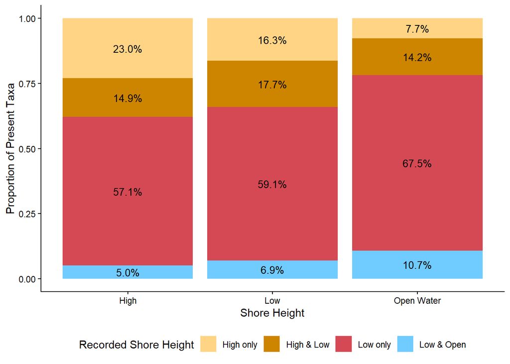

```r
shore_height_prop <- ggplot(df_summary,
                            aes(x = shorePosition, y = proportion, fill = true_category)) +
  geom_bar(stat = "identity") +
  labs(x = "Shore Height", y = "Proportion of Present Taxa", fill = "Recorded Shore Height") +
  scale_fill_manual(
    values = c(
      "high" = highshore_colour,
      "low" = lowshore_colour,
      "subtidal" = "grey70",
      "high-low" = "orange3",
      "low-open" = openwater_colour
    ),
    labels = c(
      "high" = "High only",
      "low" = "Low only",
      "subtidal" = "Open only",
      "high-low" = "High & Low",
      "low-open" = "Low & Open"
    )
  ) +
  geom_text(
    aes(label = sprintf("%.1f%%", proportion * 100)), # Format with 1 decimal place and add "%"
    position = position_stack(vjust = 0.5), # Center text within bars
    size = 3.5,
    color = "black"
  ) +
  theme_classic() +
  theme(legend.position = "bottom")

shore_height_prop
```

### Regional concordance

```r
df_summary_region <- df_long %>%
  dplyr::group_by(country, biogeography) %>%
  dplyr::summarise(n_taxa = n(), .groups = 'drop')

list.of.sw.invasives <- df_long %>%  filter(biogeography == 'invasive',
                                            country == 'Southwest England',
                                            reads > 0)
list.of.sw.invasives  <- unique(list.of.sw.invasives$scientificname)

list.of.sch.boreal <- df_long %>%  filter(biogeography == 'boreal',
                                            country == 'Scotland',
                                            reads > 0)
list.of.sch.boreal   <- unique(list.of.sch.boreal$scientificname)

# Calculate the total number of taxa in each region
df_summary_region <- df_summary_region %>%
  dplyr::group_by(country) %>%
  dplyr::mutate(total_taxa = sum(n_taxa)) %>%
  ungroup()

# Calculate the proportion of taxa in each zone within each shorePosition
df_summary_region <- df_summary_region %>%
  mutate(proportion = n_taxa / total_taxa)
```

Now plot the figure.

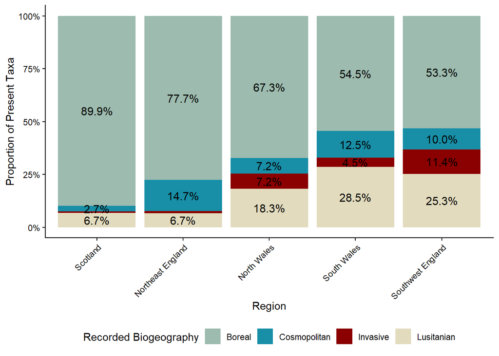

```r
region_biogeo_prop <- ggplot(df_summary_region,
                             aes(x = country, y = proportion, fill = biogeography)) +
  geom_bar(stat = "identity") +
  labs(x = "Region", y = "Proportion of Present Taxa", fill = "Recorded Biogeography") +
  scale_y_continuous(labels = scales::percent_format()) +
  scale_fill_manual(
    values = c(
      "boreal" = "#9DBBAE",
      "lusitanian" = "#E2DBBE",
      "invasive" = "red4",
      "cosmopolitan" = "#188FA7"
    ),
    labels = c(
      "boreal" = "Boreal",
      "lusitanian" = "Lusitanian",
      "invasive" = "Invasive",
      "cosmopolitan" = "Cosmopolitan"
    )
  ) +
  geom_text(
    aes(label = ifelse(
      proportion * 100 >= 1.1, sprintf("%.1f%%", proportion * 100), ""
    )),
    # Hide labels <1%
    position = position_stack(vjust = 0.5),
    # Center text within bars
    size = 4,
    color = "black"
  ) +
  theme_classic() +
  scale_x_discrete(limits = country_order) +
  theme(axis.text.x = element_text(angle = 45, hjust = 1),
        legend.position = "bottom")

region_biogeo_prop
```

Make overall figure.

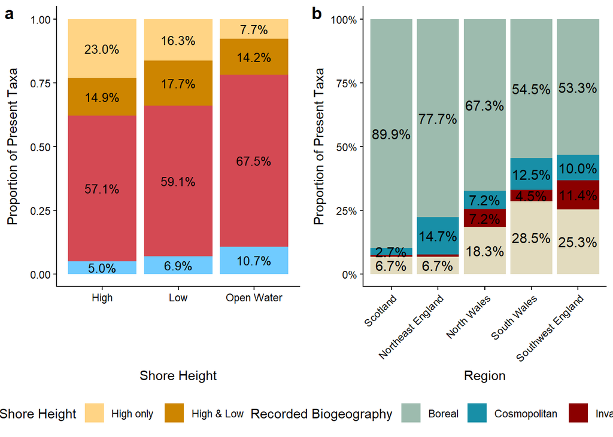

```r
concordance_plot_prop <- cowplot::plot_grid(
  shore_height_prop,
  region_biogeo_prop,
  labels = c("a", "b"),
  ncol = 2,
  align = "hv"
)
concordance_plot_prop
```

```r
ggsave(
  filename = "Figures/concordance_plot_prop.png",
  plot = concordance_plot_prop,
  device = "png",
  dpi = 600,
  units = "mm",
  height = 180,
  width = 310
)
```

## Concluding remarks

We have now created all figures and reproduced all analyses presented in the manuscript.